# PH784 Advanced Social Epidemiology: Methods

Week 6: Effect Modification and Interaction

Koichiro Shiba

kshiba@bu.edu

Boston University School of Public Health

October 14, 2025

## Today’s Plan

1. Causal estimand
   - Summarizing population health
2. Effect modification and interaction
   - Motivation
   - Estimation
   - Interpretation

## Let’s Step Back: Anatomy of Causal Estimand

$$E[Y^{a=1}]-E[Y^{a=0}]$$

**This comparison is defined based on the choice of:**

1. Hypothetical interventions to define potential outcomes
   - Well-defined treatment, directionality, regimen (time-varying, dynamic, stochastic)
2. Study population (e.g., mean among whom?)
   - Subpopulation: ATE vs CATE, ATT, ATC, etc
3. Reference (e.g., $a=0$)
   - vs natural course
4. Summary measure (e.g., mean difference)

## Summarizing Changes in Population Health

- Continuous outcome
  - Mean difference: $E[Y^{a=1}]-E[Y^{a=0}]$
- Binary outcome
  - Risk/prevalence/rate difference: e.g., $Pr[Y^{a=1}=1]-Pr[Y^{a=0}=1]$
  - Risk/prevalence/rate/odds ratio: e.g., $Pr[Y^{a=1}=1]/Pr[Y^{a=0}=1]$

**Alternative ways to summarize population health?**

## Summarizing Changes in Population Health

- Trajectories
  - Repeated outcome measures
    - Mixed-effect model
    - GEE
  - e.g., “speed” of cognitive decline (Weuve et al. 2018)

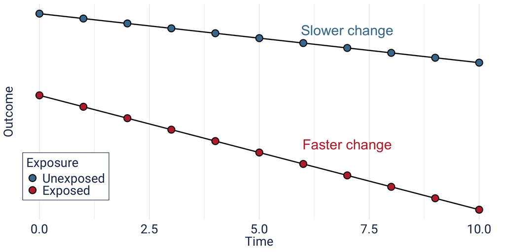

## Summarizing Changes in Population Health

### Distribution beyond mean

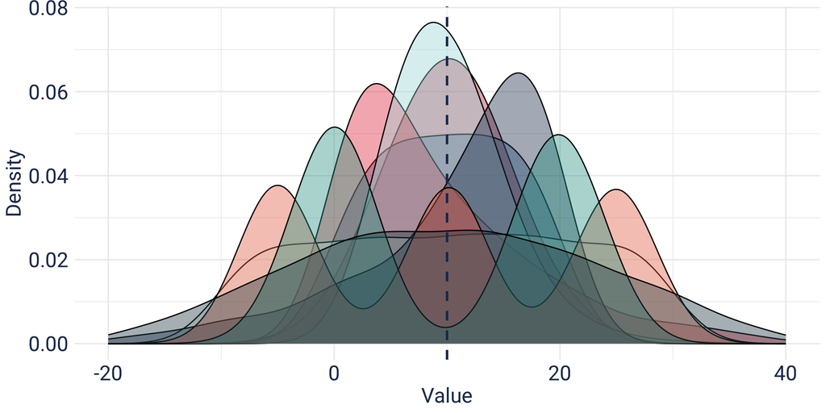

- Mean is just one way of summarizing a full distribution
  - Different distributions with the same mean
    - e.g., Example by [Thomas J Pfaff](https://briefedbydata.substack.com/p/same-mean-different-distribution)

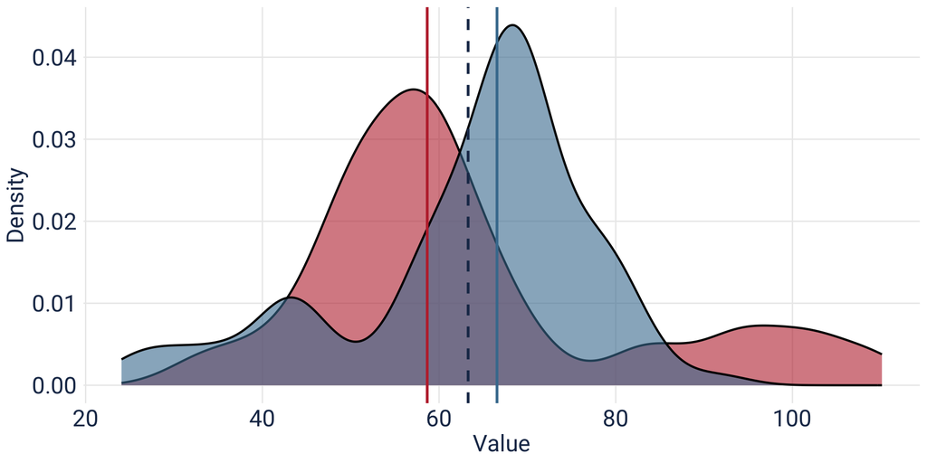

- Change in different parts of the distribution
  - e.g., Change in median
    - Quantile regression
      - Excellent tutorial by Khadka et al. (2025)

## Summarizing Changes in Population Health

### Distribution beyond mean

[figure not shown]

- Hypothetical interventions may have:
  - Same “effect” on average population health
  - Different implications for distributions
    - i.e., health disparities

Shifting the definition of “causal effect”

- “How would the hypothetical intervention change health disparities?”
  - e.g., $(E[Y^{A^g}|SES=high] - E[Y^{A^g}|SES=low]) - (E[Y|SES=high] - E[Y|SES=low])$
    - for stochastic intervention $A^g$
  - “The gap-closing estimand” (Lundberg 2024)
  - Example: Social isolation and social inequalities in all-cause mortality (Lunar et al. 2025)

- Causal effect is a contrast of two population health outcomes under hypothetical/counterfactual scenarios
  - Mean difference/ratio is not the only way to summarize population health
- Outcome trajectories
- Distributional shift
- Change in disparities

## Today’s Plan

1. Causal estimand
   - Summarizing population health
2. Effect modification and interaction
   - Motivation
   - Estimation
   - Interpretation

## Average Effect $\neq$ “Effect for All”

| ID | A | Y | Y<sup>a=1</sup> | Y<sup>a=0</sup> | Effect |
| --- | --- | --- | --- | --- | --- |
| 1 | 1 | 120 | 120 | 160 | <0 |
| 2 | 0 | 115 | 110 | 115 | <0 |
| 3 | 0 | 140 | 135 | 140 | <0 |
| 4 | 0 | 140 | 130 | 140 | <0 |
| 5 | 1 | 115 | 115 | 116 | <0 |
| 6 | 0 | 120 | 115 | 120 | <0 |
| 7 | 1 | 110 | 110 | 115 | <0 |
| 8 | 1 | 120 | 120 | 130 | <0 |
| 9 | 1 | 130 | 130 | 130 | 0 |
| 10 | 0 | 130 | 140 | 130 | >0 |

- Causal effects defined as a contrast of mean potential outcomes
  - e.g., Beneficial ATE: $E[Y_i^1 - Y_i^0] < 0$
- Individual-level effects are heterogeneous
  - $Y_i^1 - Y_i^0 < 0$ (beneficial effect)
    - $Y_{i=1}^1 - Y_{i=1}^0 = -40$
    - $Y_{i=5}^1 - Y_{i=5}^0 = -1$
  - $Y_{i=9}^1 - Y_{i=9}^0 = 0$ (no effect)
  - $Y_{i=10}^1 - Y_{i=10}^0 > 0$ (harmful effect)

**However, individual effects ($Y^{a=1}_i - Y^{a=0}_i$) are unknown**

## Practical Approach for Assessing Effect Heterogeneity

| ID | A | Y | Q |
| --- | --- | --- | --- |
| 1 | 1 | 120 | 1 |
| 2 | 0 | 115 | 1 |
| 3 | 0 | 140 | 1 |
| 4 | 0 | 140 | 1 |
| 5 | 1 | 115 | 1 |
| 6 | 0 | 120 | 0 |
| 7 | 1 | 110 | 0 |
| 8 | 1 | 120 | 0 |
| 9 | 1 | 130 | 0 |
| 10 | 0 | 130 | 0 |

- Estimate average effect among subgroups
  - Conditional average treatment effect (CATE)
- $\tau(Q=1)=E[Y_i^1 - Y_i^0|Q = 1]$
  - Average treatment effect among those with Q=1
- $\tau(Q=0)=E[Y_i^1 - Y_i^0|Q = 0]$
  - Average treatment effect among those with Q=0
- If these two CATEs were different
  - i.e., $\tau(Q=1) \neq \tau(Q=0)$
  - Effect measure modification by $Q$
    - Scale dependent (VanderWeele and Knol 2014)

## Motivation for Assessing Effect Heterogeneity

### Why does it matter?

[figure not shown]

## Effect Heterogeneity and Generalizability/Transportability

- “Is this finding applicable to different people?”
  - External validity

**Key determinants (Hernán and VanderWeele 2011)**

1. Degree of effect heterogeneity
2. Distribution of its sources

[figure not shown]

- “Contradictory” findings across methods
  - Different target populations (i.e., different estimands)
    - e.g., IV vs outcome regression
  - Both can be correct with effect heterogeneity and differential distributions of modifiers

## Effect Heterogeneity and Health Disparities

- Evidence of effect heterogeneity
  - Treatment is more effective among patients with characteristics X, Y, Z,…
  - Obvious conclusion: “Treat those individuals for whom the treatment is more effective”
    - Precision medicine (Dahabreh and Kazi 2023; Inoue et al. 2023)
- Issues with tailored interventions
  - Not always feasible
  - Not necessarily greater population impacts
  - Who are those “lucky” people?
    - Cost-effective interventions that might end up widening disparities?

## Effect Heterogeneity and Health Disparities

- Public health interventions could:
  - Narrow disparities
    - When more effective among socially marginalized groups
      - e.g., Investment in community resources
      - Vulnerable population approach (Frohlich and Potvin 2008)
  - Widen disparities
    - When less effective among socially marginalized groups
      - e.g., Health information campaigns (Federico et al. 2007)

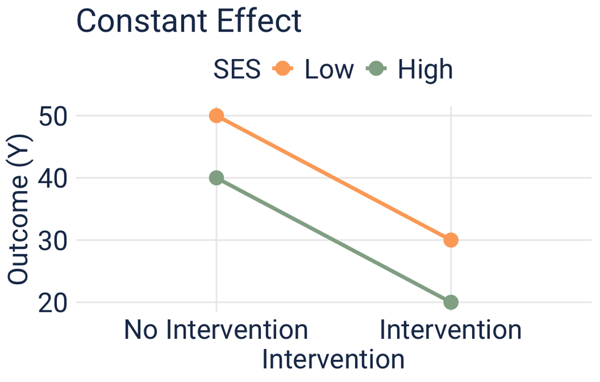

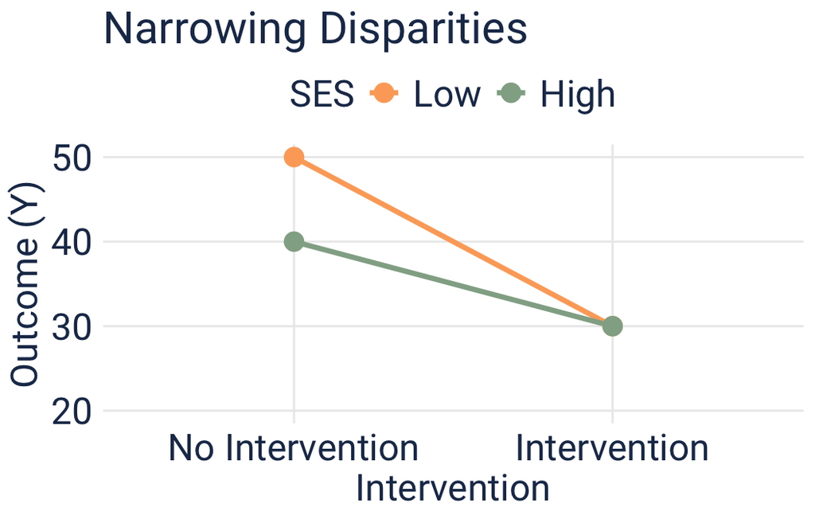

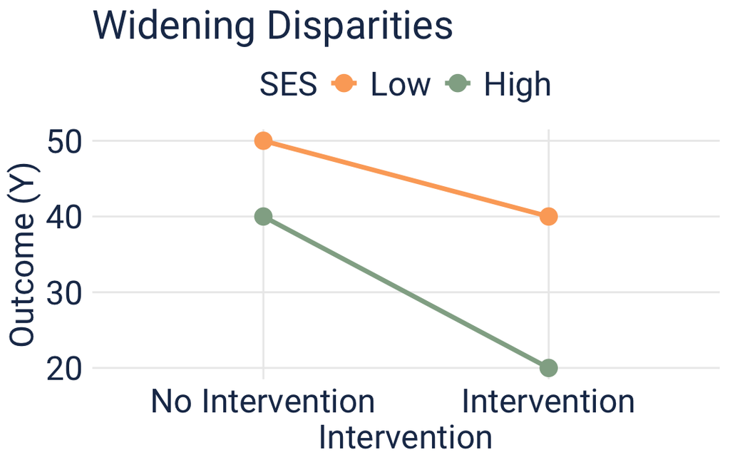

## Summary 1

- Effect heterogeneity
  - Assessment based on CATEs
- Motivation beyond “more targeted interventions”
  - Transportability
    - Effect heterogeneity and different distribution of its sources
  - Health disparities

## Today’s Plan

1. Causal estimand
   - Summarizing population health
2. Effect modification and interaction
   - Motivation
   - Estimation
   - Interpretation

## Estimating CATEs

1. Subgroup analysis
2. Parametric regression model with a product term

$$E[Y|A, Gender, Race, L] = \beta_0 + \beta_1A + \beta_2Gender + \color{#be2f3a}{\beta_3A \times Gender} \color{#1d3557}{+ \beta_4Race + L\gamma}$$

- $E[Y|A=1, Gender=0, Race, L] - E[Y|A=0, Gender=0, Race, L]$
  - Adjusted association between $A$ and $Y$ among $Gender = 0$
  - $\beta_1$
    - $E[Y|A=1, Gender=0, Race, L] = \beta_0 + \beta_1 + \beta_4Race + L\gamma$
    - $E[Y|A=0, Gender=0, Race, L] = \beta_0 + \beta_4Race + L\gamma$
- $E[Y|A=1, Gender=1, Race, L] - E[Y|A=0, Gender=1, Race, L]$
  - Adjusted association between $A$ and $Y$ among $Gender = 1$
  - $\beta_1 + \beta_3$
    - $E[Y|A=1, Gender=1, Race, L] = \beta_0 + \beta_1 + \beta_2 + \beta_3 + \beta_4Race + L\gamma$
    - $E[Y|A=0, Gender=1, Race, L] = \beta_0 + \beta_2 + \beta_4Race + L\gamma$

## Estimating CATEs

1. Subgroup analysis
2. Parametric regression model with a product term

$$E[Y|A, Gender, Race, L] = \beta_0 + \beta_1A + \beta_2Gender + \color{#be2f3a}{\beta_3A \times Gender} \color{#1d3557}{+ \beta_4Race + L\gamma}$$

- Effect by gender ($\beta_1$ for $Gender=0$ and $\beta_1 + \beta_3$ for $Gender=1$)
  - Do not call $\beta_1$ “main effect”
- This model technically estimates CATEs conditional on all covariates
  - $E[Y^{a=1}-Y^{a=0}| \color{#457b9d}{Gender, Race, L}]$

**Assumptions**

- No EMM by other variables (e.g., lack of $A \times Race$)
- No high-dimensional interactions (e.g., lack of $A \times Gender \times Race$)
  - Assumed absence of intersectionality
- All other modeling assumptions (e.g., linearity for continuous variables)

## Estimating CATEs

Limitations of parametric modeling

1. Restrictive (& unrealistic) modeling assumptions
2. Require a priori hypothesis

Non-parametric modeling

- Data-adaptive estimation via machine learning algorithms
  - Assumption-lean modeling
  - Causal forest (Shiba and Inoue 2024), meta-learners (Salditt et al. 2024)

**Benefits**

1. High-dimensional covariate set
   - CATE conditional on numerous covariates $L$: $E[Y^{a=1}-Y^{a=0}|L]$
2. Synergism
   - Naturally captures intersectionality
3. Non-linear effect heterogeneity

## High-dimensional Effect Heterogeneity: An Applied Example

### Social isolation and cognitive functioning of older adults

- Data: Health and Retirement Study (n=11,322)
- Exposure: Social isolation (dichotomized composite index)
  - Marital status and cohabitation
  - Contact with children, family, and friends
  - Social participation
- Outcome: Cognitive functioning (TICS; 0-27 points)
- Covariates: 35 pre-baseline covariates
- Analysis: Causal forest
  - Non-parametric estimation of CATE ($E[Y^{a=1}-Y^{a=0}| L]$)
  - This is NOT an individual-level effect
    - But different estimate across individuals in practice

[figure not shown]

## High-dimensional Effect Heterogeneity: An Applied Example

### Social isolation and cognitive functioning of older adults

[figure not shown]

## High-dimensional Effect Heterogeneity: An Applied Example

### Social isolation and cognitive functioning of older adults

[figure not shown]

## High-dimensional Effect Heterogeneity: An Applied Example

### Social isolation and cognitive functioning of older adults

[figure not shown]

## ML for Causal Inference: Hype or Hope?

[figure not shown]

**ML improves estimation but not identification**

- Still require the same causal identification assumptions
  - e.g., no confounding
- Not “data-driven” causal inference

## Summary 2

- Estimating CATEs
  - Subgroup analysis
  - Parametric regression with a product term
    - Underlying assumptions about effect heterogeneity
  - Non-parametric ML approach
    - High-dimensional and complex CATEs
      - Data-adaptive estimation of conditional expectations
    - Still requires the same causal identification assumptions

## Today’s Plan

1. Causal estimand
   - Summarizing population health
2. Effect modification and interaction
   - Motivation
   - Estimation
   - Interpretation

## Interpretation of Varying CATEs

### Example: The effect of social isolation on cognitive functioning by education

- $E[Y^{a=1}-Y^{a=0}|Edu=high] > E[Y^{a=1}-Y^{a=0}|Edu=low]$
  - $Y^{a=1}-Y^{a=0} < 0$ indicates decreased cognitive functioning (i.e., harmful effect)
- Interpretation?
  - Less harmful effect among those with higher educational attainment
    - Effect heterogeneity, effect (measure) modification, moderation,…
- Insights?
  1. *Prioritization/targeted interventions*
  - e.g., Use finite resources to remove social isolation among those with low education
  2. *Potential unintended consequences of interventions*
  - e.g., It is harmful and should be removed anyway
  3. *Equity*
  - e.g., Policies to prevent isolation may narrow education-based outcome disparities
  4. *How treatment effect can be altered*

## What Alters The Treatment Effect?

[figure not shown]

- Education itself
  - Education causally makes social isolation less harmful (“Get educated”)
    - e.g., Cognitively stimulating solo activities?

[figure not shown]

- Correlates of education
  - Non-causal explanation of effect heterogeneity by education
    - e.g., genes, parental education

## Alternative Causal Estimand

- Can we alter exposure effects by modifying something else (e.g., $Edu$)?
  - e.g., mitigating effects of social exposures that are hard to change
  - A hypothetical intervention targets the additional variable too
    - Joint intervention
      - $E[Y^{a=1, edu=high}-Y^{a=0,edu=high}] \neq E[Y^{a=1,edu=low}-Y^{a=0,edu=low}]$
    - Causal interaction

[figure not shown]

**Additional assumption**

- Requires identification for $Edu$
  - e.g., Conditional exchangeability for BOTH $A$ and $Edu$

## Effect Heterogeneity vs Causal Interaction

- Effect heterogeneity $E[Y^{a=1}-Y^{a=0}|L=l] \neq E[Y^{a=1}-Y^{a=0}|L=l^*]$
  - Descriptive (How does the exposure effect vary across individuals?)
  - Insights
    - Targeted interventions
    - Effect distributions (backfiring and equity implications)
    - Hypothesis generation about causal interaction
      - But acknowledge non-causal alternatives
- Causal interaction $E[Y^{a=1, l}-Y^{a=0,l}] \neq E[Y^{a=1,l^*}-Y^{a=0,l^*}]$
  - How do we alter exposure effects?
    - Making harmful exposures less harmful
    - Making beneficial exposures more beneficial
  - Explicitly estimate joint intervention effects
    - Additional causal identification

Explicitly state whether confounding adjustment was made only for exposure or for both

## Terminology

- Effect heterogeneity
  - Varying CATEs: $E[Y^{a=1}-Y^{a=0}|L=l] \neq E[Y^{a=1}-Y^{a=0}|L=l^*]$
  - Descriptive in nature
    - Statistical interaction
      - Product term
    - (Effect modification/moderation)
    - (Effect measure modification)
- Causal interaction
  - Interpretation as a joint intervention: $E[Y^{a=1, l}-Y^{a=0,l}] \neq E[Y^{a=1,l^*}-Y^{a=0,l^*}]$
- It is not productive to debate which terms to use
- Distinguish the two conceptually different causal estimand
  - CATE of $A$ conditional on $L$ versus joint intervention for $A$ and $L$

## The “WHY” of Effect Heterogeneity

### Example: The effect of social isolation on cognitive functioning by education

- $E[Y^{a=1}-Y^{a=0}|Edu=high] > E[Y^{a=1}-Y^{a=0}|Edu=low]$
  - Less harmful effect among those with higher educational attainment

**Sources of effect heterogeneity?**

- Causal interaction by:
  - Education itself
  - Correlates of education
- What else?

## The “WHY” of Effect Heterogeneity

### Example: The effect of social isolation on cognitive functioning by education

- $E[Y^{a=1}-Y^{a=0}|Edu=high] > E[Y^{a=1}-Y^{a=0}|Edu=low]$
  - Less harmful effect among those with higher educational attainment
- Multiple versions of treatment
  - Less harmful versions of social isolation among those with education?
    - e.g., living alone vs not meeting with friends regularly
    - e.g., 5 points vs 6 points (both defined as isolated with a cutoff of ≥3 points)

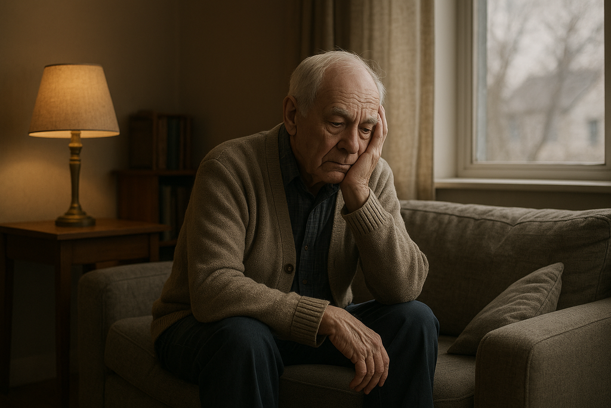

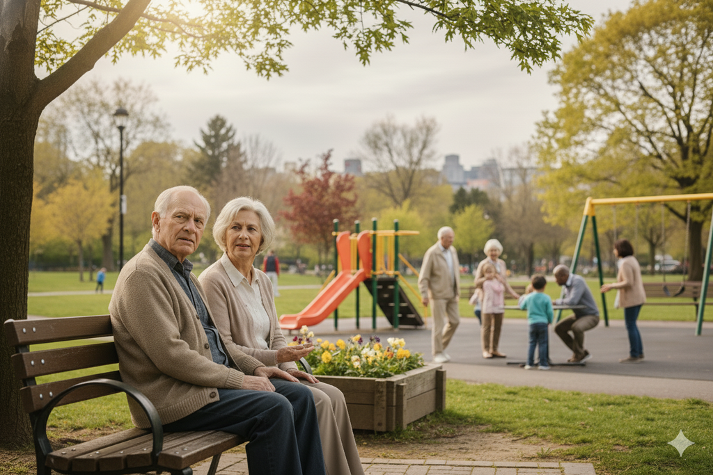

## The “WHY” of Effect Heterogeneity

### Example: The effect of social isolation on cognitive functioning by education

- $E[Y^{a=1}-Y^{a=0}|Edu=high] > E[Y^{a=1}-Y^{a=0}|Edu=low]$
  - Less harmful effect among those with higher educational attainment
- Different degree of compliance to the “one-time boost”
  - Individuals with education recover from social isolation quickly, while those with low education remain isolated?
  - Same effect if sustained?
    - $E[Y^{a=1, a_2=1}-Y^{a=0, a_2=0}|Edu=high] = E[Y^{a=1, a_2=1}-Y^{a=0, a_2=0}|Edu=low]$

[figure not shown]

## The “WHY” of Effect Heterogeneity

### Example: The effect of social isolation on cognitive functioning by education

- $E[Y^{a=1}-Y^{a=0}|Edu=high] > E[Y^{a=1}-Y^{a=0}|Edu=low]$
  - Less harmful effect among those with higher educational attainment

**Sources of effect heterogeneity**

- Causal interaction by:
  - Education itself
  - Correlates of education
- Multiple versions of treatment
- Differential treatment trajectories
- Different degree of measurement error

## Summary 3

- Insights
  - Prioritization, potential unintended consequences, equity
  - Causal interaction
    - By the covariate itself or its correlates
    - Can be explicitly estimated as a joint intervention with additional identification assumptions
- Sources of effect heterogeneity
  - Causal interaction
  - Alternative explanations
    - multiple versions, treatment trajectories, measurement error

## Population Interventions and Health Disparity

- Interventions may alter health disparities across social groups via:
  - Socially patterned effect heterogeneity
    - $E[Y^{a=1}-Y^{a=0}|L=l] \neq E[Y^{a=1}-Y^{a=0}|L=l^*]$
    - Narrow disparities if more beneficial among minoritized groups
    - Widen disparities if less beneficial among minoritized groups
  - Disproportionate change in exposure distribution
    - If minoritized groups experienced greater changes in exposure, they benefit more
    - Ignored in the “all treated” scenario of CATE

**Estimating CATEs alone is inadequate**

When do interventions result in disproportionate change in exposure?

## Population Interventions and Health Disparity

### When do interventions disproportionately change exposure distributions?

- Existing exposure disparity
  - More prevalent among the low SES group
  - Even the same relative reduction would result in greater absolute reduction
    - e.g., reducing exposure by half
      - 60% to 30% (30 percentage points reduction)
      - 40% to 20% (20 percentage points reduction)

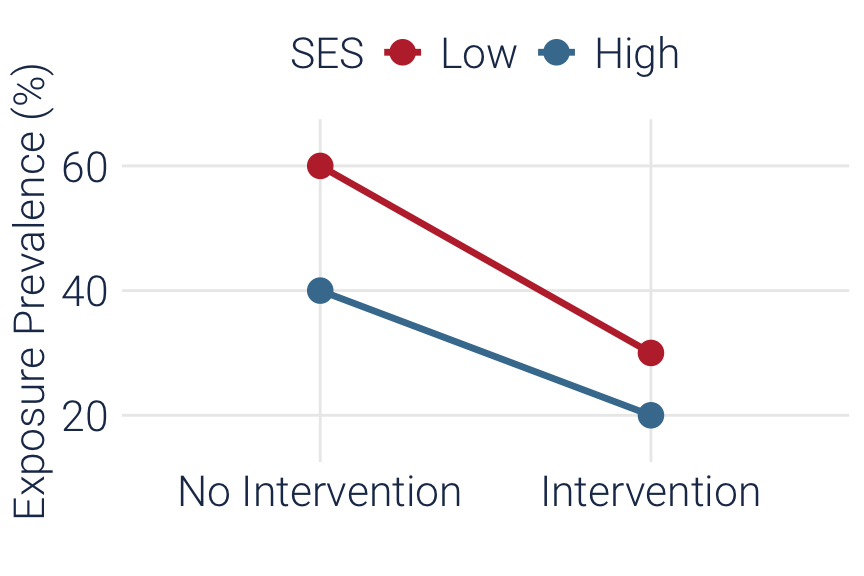

- Disproportionate reduction in the exposure
  - Even when there is no exposure disparity
    - Exposure prevalence 60% in both SES groups
      - 60% to 15% (quarter)
      - 60% to 30% (half)
    - Distinguish this from effect heterogeneity
  - *Example?*
    - Water fluoridation

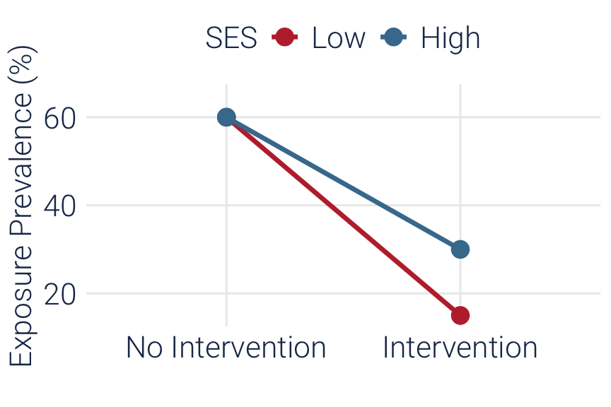

## Population Interventions and Health Disparity

### How do we simulate effects on health disparities rather than average health?

- Key ingredients of health disparities
  - Effect heterogeneity
    - $E[Y^{a=1}-Y^{a=0}|L=l] \neq E[Y^{a=1}-Y^{a=0}|L=l^*]$
  - Disproportionate changes in exposure
    - How do we incorporate disproportionate changes in exposure in causal estimand?
    - Stochastic intervention
      - Various estimators (e.g., Muñoz and Van Der Laan 2012)
        - e.g., Standardization (as in Ahern et al. 2016)

## Population Interventions and Health Disparity

### How do we simulate effects on health disparities rather than average health?

| $ID$ | $Y$ | $A$ | $L$ | $\tau(L)$ | $a=1$ | $a=0$ | $Y^{a=1}$ | $Y^{a=0}$ |
| --- | --- | --- | --- | --- | --- | --- | --- | --- |
| 1 | $Y_1$ | 1 | $\ell_1$ | $\tau_1$ | 1 | 0 | $Y_1$ | $Y_1 - \tau_1$ |
| 2 | $Y_2$ | 0 | $\ell_2$ | $\tau_2$ | 1 | 0 | $Y_2 + \tau_2$ | $Y_2$ |
| 3 | $Y_3$ | 0 | $\ell_3$ | $\tau_3$ | 1 | 0 | $Y_3 + \tau_3$ | $Y_3$ |
| $\dots$ | $\dots$ | $\dots$ | $\dots$ | $\dots$ | $\dots$ | $\dots$ | $\dots$ | $\dots$ |
| n | $Y_n$ | $A_n$ | $\ell_n$ | $\tau_n$ | 1 | 0 | $Y_n + (1 - A_n)\tau_n$ | $Y_n - A_n\tau_n$ |

- Simple standardization for static interventions
  - #1 Assign everyone to be treated $a=1$ (6th column) and untreated $a=0$ (7th column)
  - #2 Predict potential outcome under each scenario ($Y^{a=1}$ & $Y^{a=0}$)
    - Based on estimated effects $\tau_i$
  - #3 Calculate mean of $Y^{a=1}$ and mean of $Y^{a=0}$ across all individuals
  - #4 Calculate the difference between the two means & bootstrap
    - ATE: $E[Y^{a=1}]-E[Y^{a=0}]$

## Population Interventions and Health Disparity

### How do we simulate effects on health disparities rather than average health?

| $ID$ | $Y$ | $A$ | $L$ | $\tau(L)$ | $A^g$ | $Y^{A^g}$ |
| --- | --- | --- | --- | --- | --- | --- |
| 1 | $Y_1$ | 1 | $\ell_1$ | $\tau_1$ | 1 | $Y_1$ |
| 2 | $Y_2$ | 0 | $\ell_2$ | $\tau_2$ | 0 | $Y_2$ |
| 3 | $Y_3$ | 0 | $\ell_3$ | $\tau_3$ | 1 | $Y_3 + \tau_3$ |
| $\dots$ | $\dots$ | $\dots$ | $\dots$ | $\dots$ | $\dots$ | $\dots$ |
| n | $Y_n$ | $A_n$ | $\ell_n$ | $\tau_n$ | $A^g_i$ | $Y_n + (A^g_i - A_n)\tau_n$ |

- Standardization for stochastic interventions
  - #1 Assign exposure distributions under a stochastic intervention of interest
    - e.g., randomly removing exposure by 50%
    - e.g., lowering propensity scores by 50%
  - #2 Predict potential outcome $Y^{A^g}$ based on estimated effects $\tau_i$
  - #3 Calculate mean of $Y^{A^g}$ and mean of observed outcome $Y$ across all individuals
  - #4 Calculate the difference between the two means & bootstrap
    - Stochastic intervention effect: $E[Y^{A^g}]-E[Y]$
      - What would happen to the population health under the simulated stochastic intervention compared to no intervention

## Population Interventions and Health Disparity

### How do we simulate effects on health disparities rather than average health?

| $ID$ | $Y$ | $A$ | $L$ | $\tau(L)$ | $A^g$ | $Y^{A^g}$ |
| --- | --- | --- | --- | --- | --- | --- |
| 1 | $Y_1$ | 1 | $\ell_1$ | $\tau_1$ | 1 | $Y_1$ |
| 2 | $Y_2$ | 0 | $\ell_2$ | $\tau_2$ | 0 | $Y_2$ |
| 3 | $Y_3$ | 0 | $\ell_3$ | $\tau_3$ | 1 | $Y_3 + \tau_3$ |
| $\dots$ | $\dots$ | $\dots$ | $\dots$ | $\dots$ | $\dots$ | $\dots$ |
| n | $Y_n$ | $A_n$ | $\ell_n$ | $\tau_n$ | $A^g_i$ | $Y_n + (A^g_i - A_n)\tau_n$ |

- Standardization for stochastic interventions on health disparities
  - #1 Assign exposure distributions under a stochastic intervention of interest
  - #2 Predict potential outcome $Y^{A^g}$ based on estimated effects $\tau_i$
  - #3 Calculate disparities in $Y^{A^g}$ and disparities in observed outcome $Y$
    - Can use ANY disparity metric from Lecture 1
  - #4 Calculate the difference between the two disparities & bootstrap
    - e.g., $(E[Y^{A^g}|SES=high] - E[Y^{A^g}|SES=low]) - (E[Y|SES=high] - E[Y|SES=low])$
      - “How would the hypothetical intervention change SES-based health disparities?”
    - “The gap-closing estimand” (Lundberg 2024)
      - Example: Social isolation and social inequalities in all-cause mortality (Lunar et al. 2025)

## Assignment

- Problem Set #6
- Reading quiz based on:
  1. Nguyen TQ, Schmid I, Stuart EA. Clarifying causal mediation analysis for the applied researcher: Defining effects based on what we want to learn. Psychological Methods. 2021 Apr;26(2):255.
  2. Jackson JW, VanderWeele TJ. Decomposition analysis to identify intervention targets for reducing disparities. Epidemiology. 2018 Nov 1;29(6):825-35.
- Final Assignment (due October 24th at 11:59 PM)

## References

Ahern J, Colson KE, Margerson-Zilko C, Hubbard A, Galea S. Predicting the population health impacts of community interventions: The case of alcohol outlets and binge drinking. American journal of public health. 2016;106(11):1938–43.

Dahabreh IJ, Kazi DS. Toward personalizing care: Assessing heterogeneity of treatment effects in randomized trials. JAMA. 2023;329(13):1063–5.

Federico B, Costa G, Kunst AE. Educational inequalities in initiation, cessation, and prevalence of smoking among 3 italian birth cohorts. American journal of public health. 2007;97(5):838–45.

Frohlich KL, Potvin L. Transcending the known in public health practice: The inequality paradox: The population approach and vulnerable populations. American journal of public health. 2008;98(2):216–21.

Hernán MA, VanderWeele TJ. Compound treatments and transportability of causal inference. Epidemiology. 2011;22(3):368–77.

Inoue K, Athey S, Tsugawa Y. Machine-learning-based high-benefit approach versus conventional high-risk approach in blood pressure management. International journal of epidemiology. 2023;52(4):1243–56.

Khadka A, Hebert JL, Glymour MM, Jiang F, Irish A, Duchowny KA, et al. Quantile regressions as a tool to evaluate how an exposure shifts and reshapes the outcome distribution: A primer for epidemiologists. American Journal of Epidemiology. 2025;194(7):2075–84.

Lunar FR, Kondo N, Honda Y, Nakagomi A, Komura T, Inoue K, et al. Sociodemographic heterogeneity in the association between social isolation and all-cause mortality among japanese older adults: JAGES longitudinal panel study. Lancet Reg Health West Pac. 2025 Oct;63.

Lundberg I. The gap-closing estimand: A causal approach to study interventions that close disparities across social categories. Sociological Methods & Research. 2024;53(2):507–70.

Muñoz ID, Van Der Laan M. Population intervention causal effects based on stochastic interventions. Biometrics. 2012;68(2):541–9.

Salditt M, Eckes T, Nestler S. A tutorial introduction to heterogeneous treatment effect estimation with meta-learners. Administration and Policy in Mental Health and Mental Health Services Research. 2024;51(5):650–73.

Shiba K, Inoue K. Harnessing causal forests for epidemiologic research: Key considerations. American Journal of Epidemiology. 2024;193(6):813–8.

VanderWeele TJ, Knol MJ. A tutorial on interaction. Epidemiologic methods. 2014;3(1):33–72.

Weuve J, Barnes LL, De Leon CFM, Rajan KB, Beck T, Aggarwal NT, et al. Cognitive aging in black and white americans: Cognition, cognitive decline, and incidence of alzheimer disease dementia. Epidemiology. 2018;29(1):151–9.